[figure not shown]

# Mach-O Binary Data Analysis

In this notebook we're going to explore, understand, and classify Mach-O files as being 'benign' or 'malicious'. We'll start by talking how we can extract the artifacts we are interested in. Then we will explore the data, apply machine learning algorithms to the data, and the finally use those results to further explore the data.  
**DISCLAIMER:** This exercise is for illustrative purposes and only uses about 500 samples which is too small for a generalizable model.

### References

- https://developer.apple.com/library/mac/documentation/DeveloperTools/Conceptual/MachORuntime/Reference/reference.html
- https://developer.apple.com/library/mac/documentation/DeveloperTools/Conceptual/MachORuntime/Mach-O_File_Format.pdf
- http://en.wikipedia.org/wiki/Mach-O

### Python Modules Used:

- macholib: https://pythonhosted.org/macholib/
- Pandas: Python Data Analysis Library (http://pandas.pydata.org)
- Scikit Learn (http://scikit-learn.org) Scikit-learn: Machine Learning in Python, Pedregosa et al., JMLR 12, pp. 2825-2830, 2011.
- Matplotlib: Python 2D plotting library (http://matplotlib.org)

### Data generation

All data for this talk was generated using Artifactr, a highly scalable analysis engine. For more information, go to http://www.clicksecurity.com. </ shamless work plug >

### IPython Notebook for this talk: http://clicksecurity.github.io/data_hacking

[figure not shown]

## Mach-O Basic Layout

### Basic Structure

A Mach-O file contains three major regions:

1. Header Structure
2. Load Commands
3. Segments

### Header Structure

This structure identifies the file as a Mach-O file. The header also contains other basic file type information, indicates the target architecture, and contains flags specifying options that affect the interpretation of the rest of the file.

### Load Commands

Directly following the header are a series of variable-size load commands that specify the layout and linkage characteristics of the file. Among other information, the load commands can specify:

- The initial layout of the file in virtual memory
- The location of the symbol table (used for dynamic linking)
- The initial execution state of the main thread of the program
- The names of shared libraries that contain definitions for the main executable’s imported symbols

### Segments

All Mach-O files contain one or more segments. Each segment contains zero or more sections. Each section of a segment contains code or data. Each segment defines a region of virtual memory that the dynamic linker maps into the address space of the process. The exact number and layout of segments and sections is specified by the load commands and the file type.

[figure not shown]

## macholib

Current owner: Ronald Oussoren  
Description: macholib can be used to analyze and edit Mach-O headers, the executable format used by Mac OS X.  
Wasn't the easiest to get data from each load command and other data I was interested in. So we forked repo and added that ability.  
https://bitbucket.org/trogdorsey/macholib

### Imports and plot defaults

```python
import pandas as pd
print 'pandas version is', pd.__version__
import numpy as np
print 'numpy version is', np.__version__
import sklearn
print 'scikit-learn version is', sklearn.__version__
import matplotlib
print 'matplotlib version is', matplotlib.__version__
import matplotlib.pyplot as plt
```

```
pandas version is 0.13.1
numpy version is 1.8.1
scikit-learn version is 0.14.1
matplotlib version is 1.3.1
```

### Plotting defaults and helper functions

```python
%matplotlib inline
plt.rcParams['font.size'] = 18.0
plt.rcParams['figure.figsize'] = 16.0, 5.0
```

```python
def plot_cm(cm, labels):
    # Compute percentanges
    percent = (cm*100.0)/np.array(np.matrix(cm.sum(axis=1)).T)
    print 'Confusion Matrix Stats'
    for i, label_i in enumerate(labels):
        for j, label_j in enumerate(labels):
            print "%s/%s: %.2f%% (%d/%d)" % (label_i, label_j, (percent[i][j]), cm[i][j], cm[i].sum())

    # Show confusion matrix
    # Thanks to kermit666 from stackoverflow
    fig = plt.figure()
    ax = fig.add_subplot(111)
    ax.grid(b=False)
    cax = ax.matshow(percent, cmap='coolwarm',vmin=0,vmax=100)
    plt.title('Confusion matrix of the classifier')
    fig.colorbar(cax)
    ax.set_xticklabels([''] + labels)
    ax.set_yticklabels([''] + labels)
    plt.xlabel('Predicted')
    plt.ylabel('True')
    plt.show()
```

### Function to extract out the features we are interested with from the json blob

```python
def extract_features(data):
    all_features = []
    if not 'error' in data['characteristics']['macho']:
        for i in range(data['characteristics']['macho']['number of architectures']):
            features = {}
            features['entropy'] = data['metadata']['entropy']
            features['file_size'] = data['metadata']['file_size']
            features['number of architectures'] = data['characteristics']['macho']['number of architectures']
            features['header size'] = data['characteristics']['macho']['header'][i]['size']
            features['cmd count'] = data['characteristics']['macho']['header'][i]['mach header']['ncmds']
            features['cmd size'] = data['characteristics']['macho']['header'][i]['mach header']['sizeofcmds']
            features['cputype'] = data['characteristics']['macho']['header'][i]['mach header']['cputype_string']
            for flag in data['characteristics']['macho']['header'][i]['mach header']['flags']:
                features[flag['name']] = 1
            features['string count'] = data['verbose']['macho']['header'][i]['const strings count']
            if 'const strings' in data['verbose']['macho']['header'][i]:
                features['const strings'] = data['verbose']['macho']['header'][i]['const strings']
            else:
                features['const strings'] = []

            if 'symbol table strings' in data['verbose']['macho']['header'][i]:
                features['symbol table strings'] = data['verbose']['macho']['header'][i]['symbol table strings']
            else:
                features['symbol table strings'] = []
            features['segment names'] = []
            features['section names'] = []
            for command in data['verbose']['macho']['header'][i]['commands']:
                if command['cmd_name'] in ['LC_SEGMENT', 'LC_SEGMENT_64']:
                    features['segment names'].append(command['segname'])
                    if command['segname'] == '__PAGEZERO':
                        features['pz_size'] = command['cmd_size']
                        features['pz_vmsize'] = command['vmsize']
                        features['pz_vmaddr'] = command['vmaddr']
                        features['pz_flags'] = command['flags']
                        features['pz_filesize'] = command['filesize']
                        features['pz_nsects'] = command['nsects']
                        features['pz_fileoff'] = command['fileoff']
                        for flag in command['initprot']:
                            features['pz_initprot_'+flag] = 1
                        for flag in command['maxprot']:
                            features['pz_maxprot_'+flag] = 1
                    if command['segname'] == '__TEXT':
                        features['text_size'] = command['cmd_size']
                        features['text_vmsize'] = command['vmsize']
                        features['text_vmaddr'] = command['vmaddr']
                        features['text_flags'] = command['flags']
                        features['text_filesize'] = command['filesize']
                        features['text_nsects'] = command['nsects']
                        features['text_fileoff'] = command['fileoff']
                        for flag in command['initprot']:
                            features['text_initprot_'+flag] = 1
                        for flag in command['maxprot']:
                            features['text_maxprot_'+flag] = 1
                        features['text_entropy'] = command['entropy']
                        for section in command['sections']:
                            if section['sectname'] == '__text':
                                features['text_section_reloff'] = section['reloff']
                                features['text_section_addr'] = section['addr']
                                features['text_section_align'] = section['align']
                                features['text_section_nreloc'] = section['nreloc']
                                features['text_section_offset'] = section['offset']
                                features['text_section_size'] = section['size']
                                features['text_section_reserved1'] = section['reserved1']
                                features['text_section_reserved2'] = section['reserved2']
                                features['text_section_' + section['flags']['type']] = 1
                                if 'attributes' in section['flags']:
                                    for attr in section['flags']['attributes']:
                                        features['text_section_flag_attribute_'+attr] = 1
                            if section['sectname'] == '__const':
                                features['const_section_reloff'] = section['reloff']
                                features['const_section_addr'] = section['addr']
                                features['const_section_align'] = section['align']
                                features['const_section_nreloc'] = section['nreloc']
                                features['const_section_offset'] = section['offset']
                                features['const_section_size'] = section['size']
                                features['const_section_reserved1'] = section['reserved1']
                                features['const_section_reserved2'] = section['reserved2']
                                features['const_section_' + section['flags']['type']] = 1
                                if 'attributes' in section['flags']:
                                    for attr in section['flags']['attributes']:
                                        features['const_section_flag_attribute_'+attr] = 1
                    if command['segname'] == '__DATA' and command['nsects'] > 0:
                        features['data_size'] = command['cmd_size']
                        features['data_vmsize'] = command['vmsize']
                        features['data_vmaddr'] = command['vmaddr']
                        features['data_flags'] = command['flags']
                        features['data_filesize'] = command['filesize']
                        features['data_nsects'] = command['nsects']
                        features['data_fileoff'] = command['fileoff']
                        for flag in command['initprot']:
                            features['data_initprot_'+flag] = 1
                        for flag in command['maxprot']:
                            features['data_maxprot_'+flag] = 1
                        features['data_entropy'] = command['entropy']
                    #if command['segname'] == '__IMPORT':
                    #    features['import_size'] = command['cmd_size']
                    #    features['import_vmsize'] = command['vmsize']
                    #    features['import_vmaddr'] = command['vmaddr']
                    #    features['import_flags'] = command['flags']
                    #    features['import_filesize'] = command['filesize']
                    #    features['import_nsects'] = command['nsects']
                    #    features['import_fileoff'] = command['fileoff']
                    #    for flag in command['initprot']:
                    #        features['import_initprot_'+flag] = 1
                    #    for flag in command['maxprot']:
                    #        features['import_maxprot_'+flag] = 1
                    #    features['import_entropy'] = command['entropy']
                    if command['segname'] == '__LINKEDIT':
                        features['linkedit_size'] = command['cmd_size']
                        features['linkedit_vmsize'] = command['vmsize']
                        features['linkedit_vmaddr'] = command['vmaddr']
                        features['linkedit_flags'] = command['flags']
                        features['linkedit_filesize'] = command['filesize']
                        features['linkedit_nsects'] = command['nsects']
                        features['linkedit_fileoff'] = command['fileoff']
                        for flag in command['initprot']:
                            features['linkedit_initprot_'+flag] = 1
                        for flag in command['maxprot']:
                            features['linkedit_maxprot_'+flag] = 1

                    if 'sections' in command:
                        for section in command['sections']:
                            features['section names'].append(section['sectname'])
                if command['cmd_name'] == 'LC_SYMTAB':
                    features['strsize'] = command['strsize']
                    features['stroff'] = command['stroff']
                    features['symoff'] = command['symoff']
                    features['nsyms'] = command['nsyms']
                if command['cmd_name'] in ['LC_DYLD_INFO_ONLY', 'LC_DYLD_INFO']:
                    features['lazy_bind_size'] = command['lazy_bind_size']
                    features['rebase_size'] = command['rebase_size']
                    features['weak_bind_size'] = command['weak_bind_size']
                    features['lazy_bind_off'] = command['lazy_bind_off']
                    features['export_off'] = command['export_off']
                    features['export_size'] = command['export_size']
                    features['bind_off'] = command['bind_off']
                    features['rebase_off'] = command['rebase_off']
                    features['bind_size'] = command['bind_size']
                    features['weak_bind_off'] = command['weak_bind_off']
                if command['cmd_name'] == 'LC_DYSYMTAB':
                    features['nextdefsym'] = command['nextdefsym']
                    features['extreloff'] = command['extreloff']
                    features['nlocrel'] = command['nlocrel']
                    features['indirectsymoff'] = command['indirectsymoff']
                    features['modtaboff'] = command['modtaboff']
                    features['iundefsym'] = command['iundefsym']
                    features['ntoc'] = command['ntoc']
                    features['ilocalsym'] = command['ilocalsym']
                    features['nundefsym'] = command['nundefsym']
                    features['nextrefsyms'] = command['nextrefsyms']
                    features['locreloff'] = command['locreloff']
                    features['nmodtab'] = command['nmodtab']
                    features['nlocalsym'] = command['nlocalsym']
                    features['tocoff'] = command['tocoff']
                    features['extrefsymoff'] = command['extrefsymoff']
                    features['nindirectsyms'] = command['nindirectsyms']
                    features['iextdefsym'] = command['iextdefsym']
                    features['nextrel'] = command['nextrel']

            features.update(data['verbose']['macho']['header'][i]['command type count'])
            if 'LC_SEGMENT' in features:
                features['number of segments'] = features['LC_SEGMENT']
            else:
                features['number of segments'] = features['LC_SEGMENT_64']
            if 'entry point' in data['verbose']['macho']['header'][i]:
                for key, value in data['verbose']['macho']['header'][i]['entry point'].iteritems():
                    features['entry point ' + key] = value
            all_features.append(features)

    return all_features
```

```python
def load_files(file_list):
    import json
    features_list = []
    for filename in file_list:
        with open(filename,'rb') as f:
            features = extract_features(json.loads(f.read()))
            features_list.extend(features)
    return features_list
```

#### The set of good files came from my MacBook Pro running Mavericks.

```python
# Good files
import glob
good_list = glob.glob('data/good/*.results')
good_features = load_files(good_list)
print "Files:", len(good_list)
print "Number of feature vectors:", len(good_features)
```

```
Files: 266
Number of feature vectors: 337
```

#### The set of bad files came from Contagio and VirusTotal

```python
# Bad files
bad_list = glob.glob('data/bad/*.results')
bad_features = load_files(bad_list)
print "Files:", len(bad_list)
print "Number of feature vectors:", len(bad_features)
```

```
Files: 261
Number of feature vectors: 302
```

[figure not shown]

## Wait, I have more feature vectors than files?

Mach-O supports fat binaries. These are binaries that suport multiple architectures. Can have both x86 and PowerPC architectures in both 32-bit and 64-bit.  
There are 3 (or 6 when you take into consideration endianness) different magic values for MachO binaries. One (two) for 32-bit binaries, one (two) for 64-bit binaries, and one (two) for fat binaries.  
The magic value for fat binaries is cafebabe, which you might recognize as the magic value for java class files.

```python
df_good_orig = pd.DataFrame.from_records(good_features)
df_good_orig['label'] = 'good'
df_good_orig.head()
```

|  | LC_CODE_SEGMENT_SPLIT_INFO | LC_CODE_SIGNATURE | LC_DATA_IN_CODE | LC_DYLD_INFO | LC_DYLD_INFO_ONLY | LC_DYLIB_CODE_SIGN_DRS | LC_DYSYMTAB | LC_FUNCTION_STARTS | LC_ID_DYLIB | LC_LOAD_DYLIB | LC_LOAD_DYLINKER | LC_LOAD_WEAK_DYLIB | LC_MAIN | LC_REEXPORT_DYLIB | LC_RPATH | LC_SEGMENT | LC_SEGMENT_64 | LC_SOURCE_VERSION | LC_SYMTAB | LC_UNIXTHREAD |  |
| --- | --- | --- | --- | --- | --- | --- | --- | --- | --- | --- | --- | --- | --- | --- | --- | --- | --- | --- | --- | --- | --- |
| 0 | NaN | 1 | 1 | NaN | 1 | 1 | 1 | 1 | NaN | 1 | 1 | NaN | 1 | NaN | NaN | NaN | 4 | 1 | 1 | NaN | ... |
| 1 | NaN | 1 | 1 | NaN | 1 | 1 | 1 | 1 | NaN | 9 | 1 | NaN | 1 | NaN | NaN | NaN | 4 | 1 | 1 | NaN | ... |
| 2 | NaN | 1 | 1 | NaN | 1 | 1 | 1 | 1 | NaN | 9 | 1 | NaN | 1 | NaN | NaN | 4 | NaN | 1 | 1 | NaN | ... |
| 3 | NaN | 1 | 1 | NaN | 1 | 1 | 1 | 1 | NaN | 5 | 1 | NaN | 1 | NaN | NaN | NaN | 4 | 1 | 1 | NaN | ... |
| 4 | NaN | 1 | 1 | NaN | 1 | 1 | 1 | 1 | NaN | 1 | 1 | NaN | 1 | NaN | NaN | NaN | 4 | 1 | 1 | NaN | ... |

5 rows × 148 columns

```python
df_good = df_good_orig
for col in df_good.columns:
    if col[0:3] in ['LC_', 'MH_']:
        #print col
        df_good[col].fillna(0, inplace=True)

df_good.fillna(-1, inplace=True)
df_good_orig.head()
```

|  | LC_CODE_SEGMENT_SPLIT_INFO | LC_CODE_SIGNATURE | LC_DATA_IN_CODE | LC_DYLD_INFO | LC_DYLD_INFO_ONLY | LC_DYLIB_CODE_SIGN_DRS | LC_DYSYMTAB | LC_FUNCTION_STARTS | LC_ID_DYLIB | LC_LOAD_DYLIB | LC_LOAD_DYLINKER | LC_LOAD_WEAK_DYLIB | LC_MAIN | LC_REEXPORT_DYLIB | LC_RPATH | LC_SEGMENT | LC_SEGMENT_64 | LC_SOURCE_VERSION | LC_SYMTAB | LC_UNIXTHREAD |  |
| --- | --- | --- | --- | --- | --- | --- | --- | --- | --- | --- | --- | --- | --- | --- | --- | --- | --- | --- | --- | --- | --- |
| 0 | 0 | 1 | 1 | 0 | 1 | 1 | 1 | 1 | 0 | 1 | 1 | 0 | 1 | 0 | 0 | 0 | 4 | 1 | 1 | 0 | ... |
| 1 | 0 | 1 | 1 | 0 | 1 | 1 | 1 | 1 | 0 | 9 | 1 | 0 | 1 | 0 | 0 | 0 | 4 | 1 | 1 | 0 | ... |
| 2 | 0 | 1 | 1 | 0 | 1 | 1 | 1 | 1 | 0 | 9 | 1 | 0 | 1 | 0 | 0 | 4 | 0 | 1 | 1 | 0 | ... |
| 3 | 0 | 1 | 1 | 0 | 1 | 1 | 1 | 1 | 0 | 5 | 1 | 0 | 1 | 0 | 0 | 0 | 4 | 1 | 1 | 0 | ... |
| 4 | 0 | 1 | 1 | 0 | 1 | 1 | 1 | 1 | 0 | 1 | 1 | 0 | 1 | 0 | 0 | 0 | 4 | 1 | 1 | 0 | ... |

5 rows × 148 columns

```python
df_bad_orig = pd.DataFrame.from_records(bad_features)
df_bad_orig['label'] = 'bad'
df_bad = df_bad_orig
for col in df_bad.columns:
    if col[0:3] in ['LC_', 'MH_']:
        #print col
        df_bad[col].fillna(0, inplace=True)

df_bad.fillna(-1, inplace=True)
df_bad.head()
```

|  | LC_CODE_SIGNATURE | LC_DATA_IN_CODE | LC_DYLD_INFO | LC_DYLD_INFO_ONLY | LC_DYSYMTAB | LC_ENCRYPTION_INFO | LC_FUNCTION_STARTS | LC_ID_DYLIB | LC_LAZY_LOAD_DYLIB | LC_LOAD_DYLIB | LC_LOAD_DYLINKER | LC_SEGMENT | LC_SEGMENT_64 | LC_SYMTAB | LC_TWOLEVEL_HINTS | LC_UNIXTHREAD | LC_UUID | LC_VERSION_MIN_IPHONEOS | LC_VERSION_MIN_MACOSX | MH_BINDATLOAD |  |
| --- | --- | --- | --- | --- | --- | --- | --- | --- | --- | --- | --- | --- | --- | --- | --- | --- | --- | --- | --- | --- | --- |
| 0 | 0 | 0 | 1 | 0 | 1 | 0 | 0 | 0 | 0 | 8 | 1 | 0 | 4 | 1 | 0 | 1 | 1 | 0 | 0 | 0 | ... |
| 1 | 0 | 0 | 1 | 0 | 1 | 0 | 0 | 1 | 0 | 8 | 0 | 0 | 3 | 1 | 0 | 0 | 1 | 0 | 0 | 0 | ... |
| 2 | 1 | 0 | 0 | 1 | 1 | 0 | 0 | 0 | 0 | 2 | 1 | 0 | 4 | 1 | 0 | 1 | 1 | 0 | 0 | 0 | ... |
| 3 | 1 | 0 | 0 | 1 | 1 | 0 | 0 | 0 | 0 | 2 | 1 | 4 | 0 | 1 | 0 | 1 | 1 | 0 | 0 | 0 | ... |
| 4 | 1 | 1 | 0 | 1 | 1 | 0 | 1 | 0 | 0 | 11 | 0 | 4 | 0 | 1 | 0 | 0 | 1 | 0 | 1 | 0 | ... |

5 rows × 153 columns

### Let's explore the data.

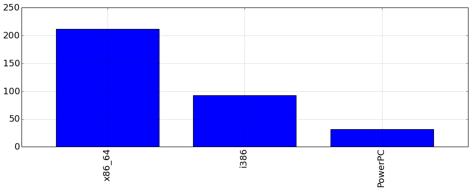

```python
df_good['cputype'].value_counts().plot(kind='bar')
```

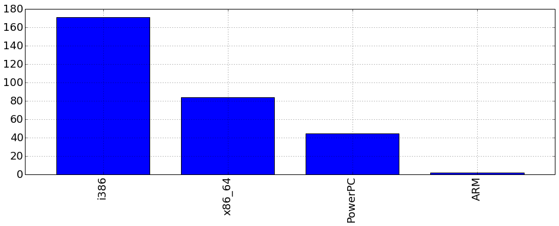

```python
df_bad['cputype'].value_counts().plot(kind='bar')
```

Let's get rid of the PowerPC cputype because that switch happened 9 years ago. I think we can all agree that malware authors won't be targeting that CPU in the future. And we probably want to examine malware for iOS devices separately.

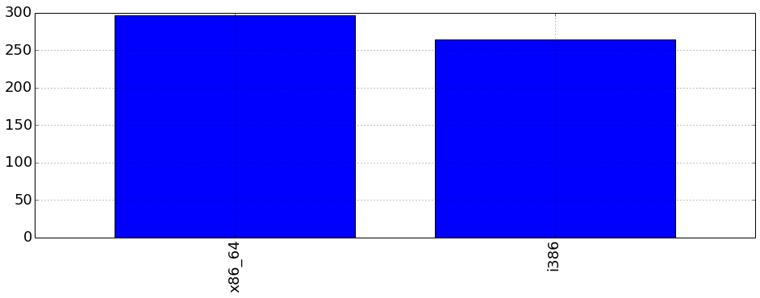

```python
df_all_orig = pd.concat([df_bad, df_good], ignore_index=True)
df_all = df_all_orig
for col in df_all.columns:
    if col[0:3] in ['LC_', 'MH_']:
        #print col
        df_all[col].fillna(0, inplace=True)

df_all.fillna(-1, inplace=True)
# Break out by cpu type
cond = df_all['cputype'] == 'x86_64'
df_x64 = df_all[cond]
cond = df_all['cputype'] == 'i386'
df_x86 = df_all[cond]
df_all = pd.concat([df_x64, df_x86], ignore_index=True)
#print df['symbol table strings']
df = df_all.drop(['const strings', 'symbol table strings', 'segment names',
                  'section names', 'entry point section name', 'entry point segment name',
                  'entry point instruction type'], axis=1)
df['cputype'].value_counts().plot(kind='bar')
```

#### Let's start to blindly explore the data

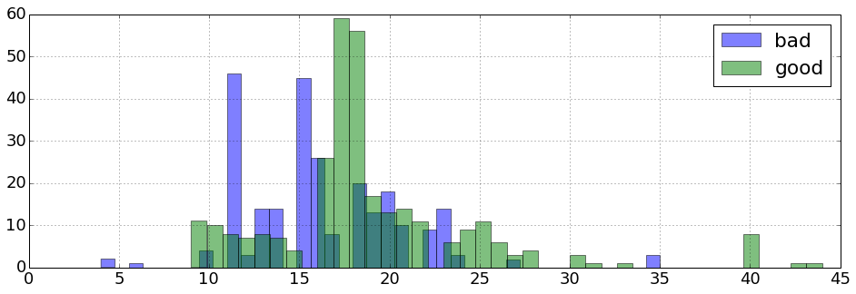

```python
cond = df['label'] == 'good'
good = df[cond]
bad  = df[~cond]
bad['cmd count'].hist(alpha=.5,label='bad',bins=40)
good['cmd count'].hist(alpha=.5,label='good',bins=40)
plt.legend()
```

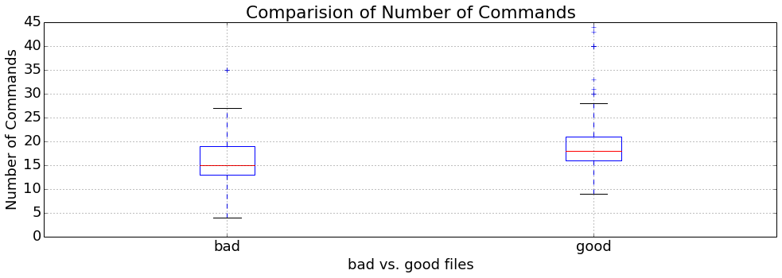

```python
df.boxplot('cmd count', 'label')
plt.xlabel('bad vs. good files')
plt.ylabel('Number of Commands')
plt.title('Comparision of Number of Commands')
plt.suptitle('')
```

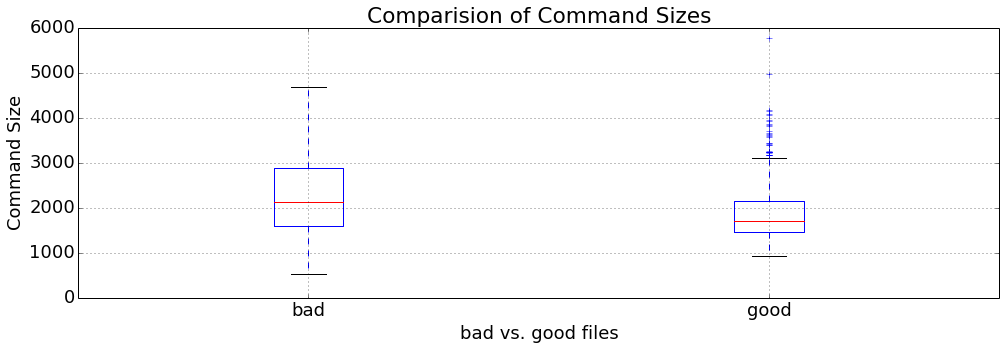

```python
df.boxplot(column='cmd size', by='label')
plt.xlabel('bad vs. good files')
plt.ylabel('Command Size')
plt.title('Comparision of Command Sizes')
plt.suptitle("")
```

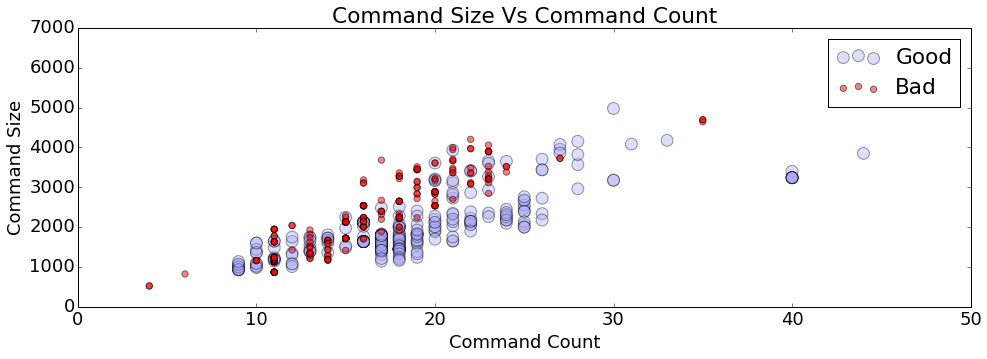

```python
# Split the classes up so we can set colors, size, labels
cond = df['label'] == 'good'
good = df[cond]
bad  = df[~cond]
plt.scatter(good['cmd count'], good['cmd size'],
            s=140, c='#aaaaff', label='Good', alpha=.4)
plt.scatter(bad['cmd count'], bad['cmd size'],
            s=40, c='r', label='Bad', alpha=.5)
plt.legend()
plt.xlabel('Command Count')
plt.ylabel('Command Size')
plt.title('Command Size Vs Command Count')
```

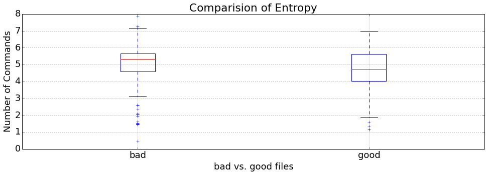

```python
df.boxplot('entropy', 'label')
plt.xlabel('bad vs. good files')
plt.ylabel('Number of Commands')
plt.title('Comparision of Entropy')
plt.suptitle('')
```

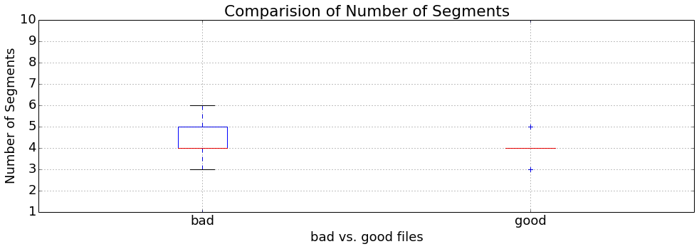

```python
df.boxplot('number of segments', 'label')
plt.xlabel('bad vs. good files')
plt.ylabel('Number of Segments')
plt.title('Comparision of Number of Segments')
plt.suptitle('')
```

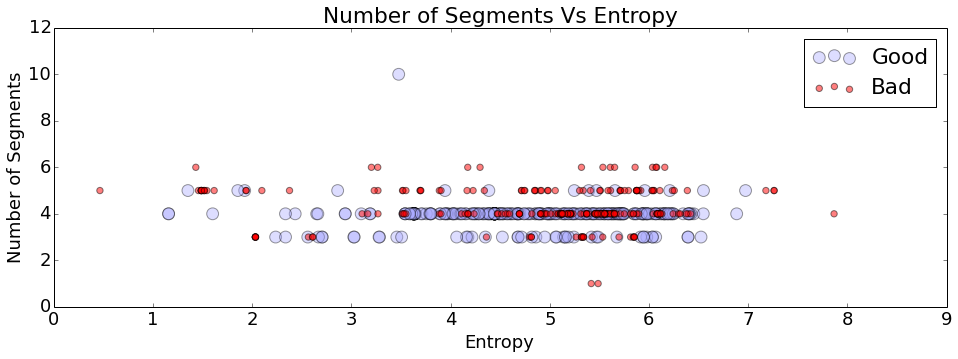

```python
cond = df['label'] == 'good'
good = df[cond]
bad  = df[~cond]
plt.scatter(good['entropy'], good['number of segments'],
            s=140, c='#aaaaff', label='Good', alpha=.4)
plt.scatter(bad['entropy'], bad['number of segments'],
            s=40, c='r', label='Bad', alpha=.5)
plt.legend()
plt.xlabel('Entropy')
plt.ylabel('Number of Segments')
plt.title('Number of Segments Vs Entropy')
```

### First we try classifying binaries just based on cmd count and cmd size

```python
# List of feature vectors (scikit learn uses 'X' for the matrix of feature vectors)
X_cmd = df.as_matrix(['cmd count', 'cmd size'])

# Labels (scikit learn uses 'y' for classification labels)
y = np.array(df['label'].tolist())
```

```python
# Random Forest is a popular ensemble machine learning classifier.
# http://scikit-learn.org/dev/modules/generated/sklearn.ensemble.RandomForestClassifier.html
#
import sklearn.ensemble
clf_cmd = sklearn.ensemble.RandomForestClassifier(n_estimators=50)
```

```python
# Now we can use scikit learn's cross validation to assess predictive performance.
scores = sklearn.cross_validation.cross_val_score(clf_cmd, X_cmd, y, cv=10)
print("Accuracy: %0.2f (+/- %0.2f)" % (scores.mean(), scores.std() * 2))
```

```
Accuracy: 0.89 (+/- 0.07)
```

```
Accuracy: 0.91
Confusion Matrix Stats
good/good: 92.75% (64/69)
good/bad: 7.25% (5/69)
bad/good: 11.63% (5/43)
bad/bad: 88.37% (38/43)
```

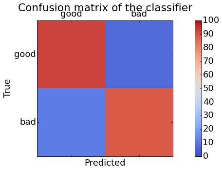

```python
my_seed = 1022
my_tsize = .2
from sklearn.cross_validation import train_test_split
X_train, X_test, y_train, y_test = train_test_split(X_cmd, y, test_size=my_tsize, random_state=my_seed)
clf_cmd.fit(X_train, y_train)
clf_cmd_scores = clf_cmd.score(X_test, y_test)
print("Accuracy: %0.2f" % clf_cmd_scores)
y_pred = clf_cmd.predict(X_test)

from sklearn.metrics import confusion_matrix
labels = ['good', 'bad']
cm = confusion_matrix(y_test, y_pred, labels)
plot_cm(cm, labels)
```

### Now try number of segments and entropy. This shouldn't work all that great.

```
Confusion Matrix Stats
good/good: 73.91% (51/69)
good/bad: 26.09% (18/69)
bad/good: 18.60% (8/43)
bad/bad: 81.40% (35/43)
```

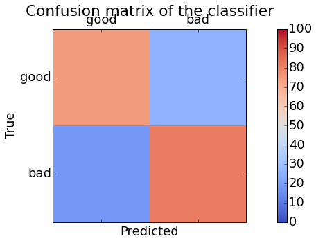

```python
clf_2 = sklearn.ensemble.RandomForestClassifier(n_estimators=50)
X_2 = df.as_matrix(['number of segments', 'entropy'])
X_train, X_test, y_train, y_test = train_test_split(X_2, y, test_size=my_tsize, random_state=my_seed)
clf_2.fit(X_train, y_train)
y_pred = clf_2.predict(X_test)

from sklearn.metrics import confusion_matrix
labels = ['good', 'bad']
cm = confusion_matrix(y_test, y_pred, labels)
plot_cm(cm, labels)
```

### Okay now try putting in ALL the features... except the label, which would be cheating. And the cputype, which is a string.

```
Confusion Matrix Stats
good/good: 92.75% (64/69)
good/bad: 7.25% (5/69)
bad/good: 6.98% (3/43)
bad/bad: 93.02% (40/43)
```

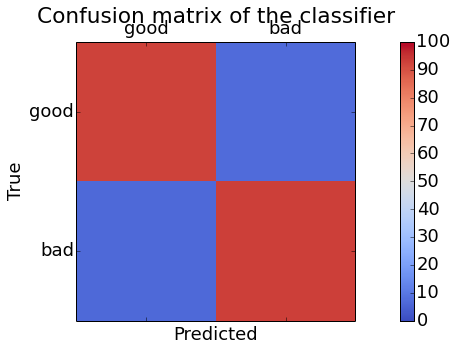

```python
clf_all = sklearn.ensemble.RandomForestClassifier(n_estimators=50)
no_label = list(df.columns.values)
no_label.remove('label')
no_label.remove('cputype')
X = df.as_matrix(no_label)

# 80/20 Split for predictive test
X_train, X_test, y_train, y_test = train_test_split(X, y, test_size=my_tsize, random_state=my_seed)
clf_all.fit(X_train, y_train)
y_pred = clf_all.predict(X_test)
cm = confusion_matrix(y_test, y_pred, labels)
plot_cm(cm, labels)
```

```python
# Feature Selection
# Which features best deferentiated the two classes?
# Here we're going to grab the feature_importances from the classifier itself,
importances = zip(no_label, clf_all.feature_importances_)
importances.sort(key=lambda k:k[1], reverse=True)
for im in importances[0:20]:
    print im[0].ljust(30), im[1]
```

```
LC_UNIXTHREAD                  0.11111604246
LC_CODE_SIGNATURE              0.0500117721965
rebase_off                     0.0407851853834
LC_MAIN                        0.0385643285089
text_section_align             0.0339347105743
LC_DYLIB_CODE_SIGN_DRS         0.0335313105805
LC_DYLD_INFO_ONLY              0.0304556902729
linkedit_filesize              0.029905256752
MH_PIE                         0.0226196128034
LC_SOURCE_VERSION              0.0198478375291
pz_size                        0.0178616171746
rebase_size                    0.017668781554
text_section_addr              0.0159335856278
data_entropy                   0.0156907971405
LC_FUNCTION_STARTS             0.0150161007743
data_size                      0.0149447133839
linkedit_vmsize                0.014562058373
const_section_size             0.0135111773331
extreloff                      0.0132383705557
LC_VERSION_MIN_MACOSX          0.0127062868088
```

### Closer look at important features

The LC_UNIXTHREAD command defines the entry point into the executable. In 10.8 and above, this was replaced by LC_MAIN. As stated above, I grabbed my clean binaries from my laptop, which is running Mavericks (10.9). The malware was grabbed from Contagio and VirusTotal, with no thought as to what version it was compiled on.

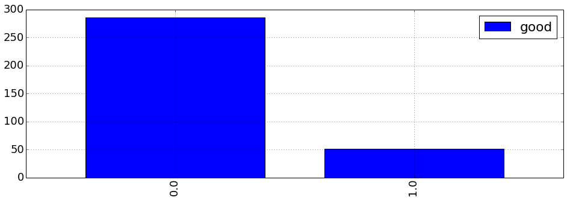

```python
df_good['LC_UNIXTHREAD'].value_counts().plot(kind='bar', label='good')
plt.legend()
```

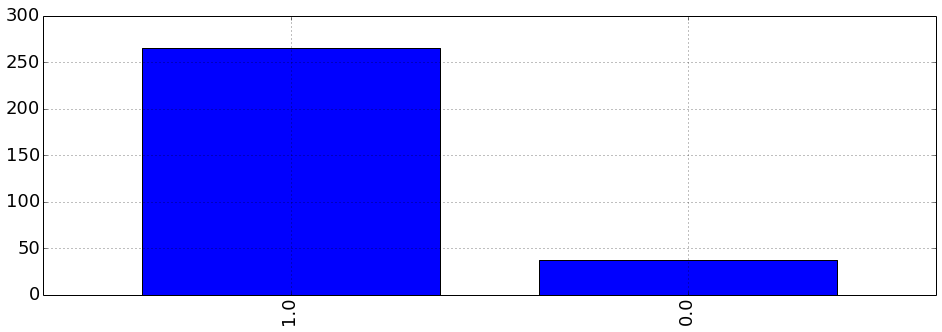

```python
df_bad['LC_UNIXTHREAD'].value_counts().plot(kind='bar')
```

My clean set clearly has a sample bias towards LC_MAIN. We do not want to overfit our model and since we would like our classifier to be agnostic to OS version, we will remove those labels.  
Over fitting problems: https://www.youtube.com/watch?v=DQWI1kvmwRg

#### Now try all the same features as before, but without LC_UNIXTHREAD and LC_MAIN

```
Confusion Matrix Stats
good/good: 95.65% (66/69)
good/bad: 4.35% (3/69)
bad/good: 6.98% (3/43)
bad/bad: 93.02% (40/43)
```

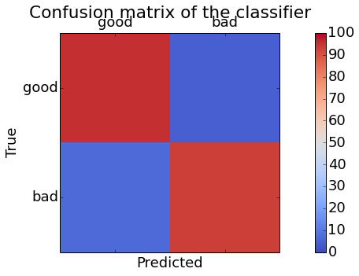

```python
clf_some = sklearn.ensemble.RandomForestClassifier(n_estimators=50)
some = list(df.columns.values)
some.remove('label')
some.remove('cputype')
some.remove('LC_UNIXTHREAD')
some.remove('LC_MAIN')
X_some = df.as_matrix(some)

# 80/20 Split for predictive test
X_train_some, X_test_some, y_train_some, y_test_some = train_test_split(X_some, y, test_size=my_tsize, random_state=my_seed)
clf_some.fit(X_train_some, y_train_some)
y_pred_some = clf_some.predict(X_test_some)
cm = confusion_matrix(y_test_some, y_pred_some, labels)
plot_cm(cm, labels)
```

Hey, it's the same(ish). That's kinda nice.

```python
importances = zip(some, clf_some.feature_importances_)
importances.sort(key=lambda k:k[1], reverse=True)
for im in importances[0:20]:
    print im[0].ljust(30), im[1]
```

```
rebase_off                     0.0833325758996
text_section_align             0.0428642619275
LC_SOURCE_VERSION              0.0414863657063
LC_DYLIB_CODE_SIGN_DRS         0.0390404405528
linkedit_filesize              0.0343569215656
rebase_size                    0.0268211203307
LC_FUNCTION_STARTS             0.0258331878885
LC_DATA_IN_CODE                0.0257389166901
LC_VERSION_MIN_MACOSX          0.0248798919781
LC_CODE_SIGNATURE              0.0231596346234
pz_size                        0.0230647740647
LC_DYLD_INFO_ONLY              0.0227836821431
MH_PIE                         0.0197788472089
data_nsects                    0.0193926037336
pz_vmaddr                      0.0180289427176
lazy_bind_size                 0.0156826479795
linkedit_vmsize                0.0142413695731
cmd count                      0.0137541943859
nlocrel                        0.0130961872487
bind_off                       0.012773950971
```

### What about the strings?

```python
symbol_strings = []
for strings, label in zip(df_all['symbol table strings'], df_all['label']):
    for symbol in strings:
        symbol_strings.append({'symbol string': symbol, 'label': label})

pd_symbols = pd.DataFrame.from_records(symbol_strings)
pd_symbols.head()
```

|  | label | symbol string |
| --- | --- | --- |
| 0 | bad | __mh_execute_header |
| 1 | bad | _AuthorizationCreate |
| 2 | bad | _AuthorizationExecuteWithPrivileges |
| 3 | bad | _BIO_ctrl |
| 4 | bad | _BIO_f_base64 |

5 rows × 2 columns

```python
import sys
sys.path.insert(0,'..')
import data_hacking.simple_stats as ss
```

```python
# Spin up our g_test class
g_test = ss.GTest()

# Here we'd like to see how strongly various strings are assoicated with being clean or malware.
df_ct, df_cd, df_symbol_stats = g_test.highest_gtest_scores(pd_symbols['symbol string'],
                                                            pd_symbols['label'], N=0, matches=0, min_volume=5)
```

```python
df_symbol_stats.dropna(inplace=True)
df_symbol_stats.sort('bad_g', ascending=0).head(25)
```

|  | bad | good | bad_cd | good_cd | total_cd | bad_exp | bad_g | good_exp | good_g |
| --- | --- | --- | --- | --- | --- | --- | --- | --- | --- |
| H1\x8d5A`\x02 | 4836 | 0 | 1.000000 | 0.000000 | 4836 | 3570.141890 | 2935.283635 | 1265.858110 | 0.000000 |
| L\x89\xe7\xff\x158`\x02 | 4836 | 0 | 1.000000 | 0.000000 | 4836 | 3570.141890 | 2935.283635 | 1265.858110 | 0.000000 |
| __ZStL8__ioinit | 160 | 0 | 1.000000 | 0.000000 | 160 | 118.118838 | 97.114430 | 41.881162 | 0.000000 |
| ___tcf_0 | 113 | 6 | 0.949580 | 0.050420 | 119 | 87.850886 | 56.894804 | 31.149114 | -19.764316 |
| __ZN5boost6systemL14posix_categoryE | 92 | 0 | 1.000000 | 0.000000 | 92 | 67.918332 | 55.840797 | 24.081668 | 0.000000 |
| __ZN5boost6systemL11native_ecatE | 92 | 0 | 1.000000 | 0.000000 | 92 | 67.918332 | 55.840797 | 24.081668 | 0.000000 |
| __ZN5boost6systemL10errno_ecatE | 92 | 0 | 1.000000 | 0.000000 | 92 | 67.918332 | 55.840797 | 24.081668 | 0.000000 |
| __GLOBAL__I_a | 94 | 1 | 0.989474 | 0.010526 | 95 | 70.133060 | 55.065291 | 24.866940 | -6.427078 |
| ___cxx_global_var_init | 90 | 0 | 1.000000 | 0.000000 | 90 | 66.441847 | 54.626867 | 23.558153 | 0.000000 |
| __Z41__static_initialization_and_destruction_0ii | 111 | 7 | 0.940678 | 0.059322 | 118 | 87.112643 | 53.796854 | 30.887357 | -20.782115 |
| ___cxx_global_var_init2 | 88 | 0 | 1.000000 | 0.000000 | 88 | 64.965361 | 53.412936 | 23.034639 | 0.000000 |
| ___cxx_global_var_init3 | 88 | 0 | 1.000000 | 0.000000 | 88 | 64.965361 | 53.412936 | 23.034639 | 0.000000 |
| ___cxx_global_var_init4 | 88 | 0 | 1.000000 | 0.000000 | 88 | 64.965361 | 53.412936 | 23.034639 | 0.000000 |
| ___cxx_global_var_init1 | 88 | 0 | 1.000000 | 0.000000 | 88 | 64.965361 | 53.412936 | 23.034639 | 0.000000 |
| __ZN12_GLOBAL__N_12_1E | 86 | 0 | 1.000000 | 0.000000 | 86 | 63.488876 | 52.199006 | 22.511124 | 0.000000 |
| __ZN12_GLOBAL__N_12_5E | 86 | 0 | 1.000000 | 0.000000 | 86 | 63.488876 | 52.199006 | 22.511124 | 0.000000 |
| ___cxx_global_var_init8 | 86 | 0 | 1.000000 | 0.000000 | 86 | 63.488876 | 52.199006 | 22.511124 | 0.000000 |
| __ZN12_GLOBAL__N_12_9E | 86 | 0 | 1.000000 | 0.000000 | 86 | 63.488876 | 52.199006 | 22.511124 | 0.000000 |
| __ZN12_GLOBAL__N_12_2E | 86 | 0 | 1.000000 | 0.000000 | 86 | 63.488876 | 52.199006 | 22.511124 | 0.000000 |
| ___cxx_global_var_init9 | 86 | 0 | 1.000000 | 0.000000 | 86 | 63.488876 | 52.199006 | 22.511124 | 0.000000 |
| __ZN12_GLOBAL__N_12_8E | 86 | 0 | 1.000000 | 0.000000 | 86 | 63.488876 | 52.199006 | 22.511124 | 0.000000 |
| ___cxx_global_var_init11 | 86 | 0 | 1.000000 | 0.000000 | 86 | 63.488876 | 52.199006 | 22.511124 | 0.000000 |
| __ZN12_GLOBAL__N_12_7E | 86 | 0 | 1.000000 | 0.000000 | 86 | 63.488876 | 52.199006 | 22.511124 | 0.000000 |
| ___cxx_global_var_init6 | 86 | 0 | 1.000000 | 0.000000 | 86 | 63.488876 | 52.199006 | 22.511124 | 0.000000 |
| ___cxx_global_var_init5 | 86 | 0 | 1.000000 | 0.000000 | 86 | 63.488876 | 52.199006 | 22.511124 | 0.000000 |

25 rows × 9 columns

```python
df_symbol_stats.sort('good_g', ascending=0).head(25)
```

|  | bad | good | bad_cd | good_cd | total_cd | bad_exp | bad_g | good_exp | good_g |
| --- | --- | --- | --- | --- | --- | --- | --- | --- | --- |
| dyld_stub_binder | 173 | 276 | 0.385301 | 0.614699 | 449 | 331.470990 | -224.986050 | 117.529010 | 471.251050 |
| radr://5614542 | 107 | 236 | 0.311953 | 0.688047 | 343 | 253.217260 | -184.343670 | 89.782740 | 456.159232 |
| ___stderrp | 35 | 187 | 0.157658 | 0.842342 | 222 | 163.889888 | -108.069271 | 58.110112 | 437.119579 |
| _strcmp | 51 | 169 | 0.231818 | 0.768182 | 220 | 162.413403 | -118.148571 | 57.586597 | 363.893795 |
| ___stack_chk_fail | 92 | 190 | 0.326241 | 0.673759 | 282 | 208.184453 | -150.261006 | 73.815547 | 359.272784 |
| ___stack_chk_guard | 92 | 190 | 0.326241 | 0.673759 | 282 | 208.184453 | -150.261006 | 73.815547 | 359.272784 |
| _fprintf | 39 | 156 | 0.200000 | 0.800000 | 195 | 143.957334 | -101.864515 | 51.042666 | 348.564572 |
| ___stdoutp | 8 | 120 | 0.062500 | 0.937500 | 128 | 94.495071 | -39.505698 | 33.504929 | 306.191801 |
| __mh_execute_header | 218 | 225 | 0.492099 | 0.507901 | 443 | 327.041534 | -176.838162 | 115.958466 | 298.290746 |
| _printf | 46 | 123 | 0.272189 | 0.727811 | 169 | 124.763023 | -91.795275 | 44.236977 | 251.565340 |
| ___stdinp | 0 | 93 | 0.000000 | 1.000000 | 93 | 68.656575 | 0.000000 | 24.343425 | 249.302811 |
| _fwrite | 55 | 116 | 0.321637 | 0.678363 | 171 | 126.239509 | -91.393256 | 44.760491 | 220.925324 |
| _fputc | 32 | 101 | 0.240602 | 0.759398 | 133 | 98.186284 | -71.752361 | 34.813716 | 215.152034 |
| ___error | 85 | 127 | 0.400943 | 0.599057 | 212 | 156.507461 | -103.776912 | 55.492539 | 210.296380 |
| ___snprintf_chk | 0 | 78 | 0.000000 | 1.000000 | 78 | 57.582934 | 0.000000 | 20.417066 | 209.092680 |
| _exit | 230 | 189 | 0.548926 | 0.451074 | 419 | 309.323708 | -136.302148 | 109.676292 | 205.712812 |
| _puts | 27 | 89 | 0.232759 | 0.767241 | 116 | 85.636158 | -62.330620 | 30.363842 | 191.418329 |
| _optind | 5 | 74 | 0.063291 | 0.936709 | 79 | 58.321176 | -24.565273 | 20.678824 | 188.693330 |
| _strncmp | 28 | 88 | 0.241379 | 0.758621 | 116 | 85.636158 | -62.602573 | 30.363842 | 187.278840 |
| _putchar | 6 | 74 | 0.075000 | 0.925000 | 80 | 59.059419 | -27.441415 | 20.940581 | 186.831670 |
| _optarg | 1 | 69 | 0.014286 | 0.985714 | 70 | 51.676992 | -7.890025 | 18.323008 | 182.980956 |
| _strtol | 8 | 73 | 0.098765 | 0.901235 | 81 | 59.797662 | -32.184400 | 21.202338 | 180.506805 |
| _stat$INODE64 | 21 | 80 | 0.207921 | 0.792079 | 101 | 74.562517 | -53.218850 | 26.437483 | 177.159010 |
| _strlen | 171 | 150 | 0.532710 | 0.467290 | 321 | 236.975920 | -111.592881 | 84.024080 | 173.859559 |
| ___maskrune | 15 | 73 | 0.170455 | 0.829545 | 88 | 64.965361 | -43.974121 | 23.034639 | 168.405207 |

25 rows × 9 columns

```python
def tokenize_string(string):
    if '___cxx_global_var_init' in string:
        return '___cxx_global_var_init_TOKEN'
    elif '__ZN12_GLOBAL' in string:
        return '__ZN12_GLOBAL_TOKEN'
    else:
        return string
```

```python
pd_symbols['tokenized string'] = pd_symbols['symbol string'].map(lambda x: tokenize_string(x))
```

```python
df_ct, df_cd, df_symbol_stats = g_test.highest_gtest_scores(pd_symbols['tokenized string'],
                                                     pd_symbols['label'], N=10, matches=5, min_volume=5)
```

```python
df_symbol_stats.dropna(inplace=True)
df_symbol_stats.sort('bad_g', ascending=0).head(10)
```

|  | bad | good | bad_cd | good_cd | total_cd | bad_exp | bad_g | good_exp | good_g |
| --- | --- | --- | --- | --- | --- | --- | --- | --- | --- |
| L\x89\xe7\xff\x158`\x02 | 4836 | 0 | 1.000000 | 0.000000 | 4836 | 4428.513498 | 851.367726 | 407.486502 | 0.000000 |
| H1\x8d5A`\x02 | 4836 | 0 | 1.000000 | 0.000000 | 4836 | 4428.513498 | 851.367726 | 407.486502 | 0.000000 |
| ___cxx_global_var_init_TOKEN | 1560 | 0 | 1.000000 | 0.000000 | 1560 | 1428.552741 | 274.634750 | 131.447259 | 0.000000 |
| __ZN12_GLOBAL_TOKEN | 870 | 5 | 0.994286 | 0.005714 | 875 | 801.271570 | 143.190314 | 73.728430 | -26.909506 |
| _malloc | 160 | 130 | 0.551724 | 0.448276 | 290 | 265.564292 | -162.138608 | 24.435708 | 434.587122 |
| _strlen | 171 | 150 | 0.532710 | 0.467290 | 321 | 293.952199 | -185.279734 | 27.047801 | 513.908873 |
| radr://5614542 | 107 | 236 | 0.311953 | 0.688047 | 343 | 314.098455 | -230.451818 | 28.901545 | 991.170152 |
| _exit | 230 | 189 | 0.548926 | 0.451074 | 419 | 383.694615 | -235.413120 | 35.305385 | 634.174947 |
| __mh_execute_header | 218 | 225 | 0.492099 | 0.507901 | 443 | 405.672349 | -270.778127 | 37.327651 | 808.364717 |
| dyld_stub_binder | 173 | 276 | 0.385301 | 0.614699 | 449 | 411.166783 | -299.534738 | 37.833217 | 1096.941787 |

10 rows × 9 columns

```python
def g_aggregate(df_stats, sequence, name):
    try:
        g_scores = [df_stats.ix[tokenize_string(item)][name] for item in sequence]
    except KeyError:
        return 0
    return sum(g_scores)/len(g_scores) if g_scores else 0 # Average
```

```python
df_all['symbol table strings malicious_g'] = \
    df_all['symbol table strings'].map(lambda x: g_aggregate(df_symbol_stats, x, 'bad_g'))
df_all['symbol table strings clean_g'] = \
    df_all['symbol table strings'].map(lambda x: g_aggregate(df_symbol_stats, x, 'good_g'))
```

```python
segment_names = []
for strings, label in zip(df_all['segment names'], df_all['label']):
    for name in strings:
        segment_names.append({'segment names': name, 'label': label})

pd_segment_names = pd.DataFrame.from_records(segment_names)
pd_segment_names.head()
```

|  | label | segment names |
| --- | --- | --- |
| 0 | bad | __PAGEZERO |
| 1 | bad | __TEXT |
| 2 | bad | __DATA |
| 3 | bad | __LINKEDIT |
| 4 | bad | __TEXT |

5 rows × 2 columns

```python
#Spin up our g_test class
g_test = ss.GTest()

df_ct, df_cd, df_segment_stats = g_test.highest_gtest_scores(pd_segment_names['segment names'],
                                                     pd_segment_names['label'], N=0, matches=0, min_volume=0)
```

```python
df_segment_stats.dropna(inplace=True)
df_segment_stats.sort('bad_g', ascending=0).head(10)
```

|  | bad | good | bad_cd | good_cd | total_cd | bad_exp | bad_g | good_exp | good_g |
| --- | --- | --- | --- | --- | --- | --- | --- | --- | --- |
| __OBJC | 55 | 17 | 0.763889 | 0.236111 | 72 | 34.263158 | 52.058877 | 37.736842 | -27.112400 |
| __IMPORT | 48 | 28 | 0.631579 | 0.368421 | 76 | 36.166667 | 27.174060 | 39.833333 | -19.739976 |
| __PAGEZERO | 218 | 225 | 0.492099 | 0.507901 | 443 | 210.813596 | 14.615046 | 232.186404 | -14.148050 |
|  | 3 | 0 | 1.000000 | 0.000000 | 3 | 1.427632 | 4.455573 | 1.572368 | 0.000000 |
| __INIT_STUB | 2 | 0 | 1.000000 | 0.000000 | 2 | 0.951754 | 2.970382 | 1.048246 | 0.000000 |
| .ida | 0 | 4 | 0.000000 | 1.000000 | 4 | 1.903509 | 0.000000 | 2.096491 | 5.168234 |
| __LINKEDIT | 253 | 305 | 0.453405 | 0.546595 | 558 | 265.539474 | -24.477253 | 292.460526 | 25.609064 |
| __TEXT | 253 | 305 | 0.453405 | 0.546595 | 558 | 265.539474 | -24.477253 | 292.460526 | 25.609064 |
| __DATA | 253 | 311 | 0.448582 | 0.551418 | 564 | 268.394737 | -29.889069 | 295.605263 | 31.577645 |

9 rows × 9 columns

```python
s = []
for strings, label in zip(df_all['section names'], df_all['label']):
    for name in strings:
        s.append({'section names': name, 'label': label})

pd_section_names = pd.DataFrame.from_records(s)
print pd_section_names.shape
pd_section_names.head()
```

```
(8289, 2)
```

|  | label | section names |
| --- | --- | --- |
| 0 | bad | __text |
| 1 | bad | __symbol_stub1 |
| 2 | bad | __stub_helper |
| 3 | bad | __cstring |
| 4 | bad | __unwind_info |

5 rows × 2 columns

```python
#Spin up our g_test class
g_test = ss.GTest()

# Here we'd like to see how various exploits (description) are related to
# the ASN (Autonomous System Number) associated with the ip/domain.
df_ct, df_cd, df_section_stats = g_test.highest_gtest_scores(pd_section_names['section names'],
                                                     pd_section_names['label'], N=0, matches=0, min_volume=5)
```

```python
df_section_stats.dropna(inplace=True)
df_section_stats.sort('bad_g', ascending=0).head(10)
```

|  | bad | good | bad_cd | good_cd | total_cd | bad_exp | bad_g | good_exp | good_g |
| --- | --- | --- | --- | --- | --- | --- | --- | --- | --- |
| __dyld | 192 | 53 | 0.783673 | 0.216327 | 245 | 125.706961 | 162.640082 | 119.293039 | -85.996853 |
| __symbol_stub1 | 55 | 1 | 0.982143 | 0.017857 | 56 | 28.733020 | 71.421483 | 27.266980 | -6.611353 |
| __symbol_stub | 124 | 62 | 0.666667 | 0.333333 | 186 | 95.434672 | 64.936223 | 90.565328 | -46.988195 |
| __common | 212 | 156 | 0.576087 | 0.423913 | 368 | 188.816986 | 49.102615 | 179.183014 | -43.228130 |
| __instance_vars | 43 | 6 | 0.877551 | 0.122449 | 49 | 25.141392 | 46.154870 | 23.858608 | -16.564627 |
| __cls_refs | 50 | 12 | 0.806452 | 0.193548 | 62 | 31.811557 | 45.219334 | 30.188443 | -22.141260 |
| __message_refs | 50 | 12 | 0.806452 | 0.193548 | 62 | 31.811557 | 45.219334 | 30.188443 | -22.141260 |
| __module_info | 51 | 13 | 0.796875 | 0.203125 | 64 | 32.837737 | 44.905221 | 31.162263 | -22.730721 |
| __meta_class | 44 | 8 | 0.846154 | 0.153846 | 52 | 26.680661 | 44.022056 | 25.319339 | -18.434031 |
| __symbols | 44 | 8 | 0.846154 | 0.153846 | 52 | 26.680661 | 44.022056 | 25.319339 | -18.434031 |

10 rows × 9 columns

```python
df_section_stats.sort('good_g', ascending=0).head(10)
```

|  | bad | good | bad_cd | good_cd | total_cd | bad_exp | bad_g | good_exp | good_g |
| --- | --- | --- | --- | --- | --- | --- | --- | --- | --- |
| __stubs | 28 | 210 | 0.117647 | 0.882353 | 238 | 122.115334 | -82.474641 | 115.884666 | 249.695077 |
| __got | 29 | 171 | 0.145000 | 0.855000 | 200 | 102.617927 | -73.295575 | 97.382073 | 192.553326 |
| __unwind_info | 192 | 301 | 0.389452 | 0.610548 | 493 | 252.953191 | -105.872288 | 240.046809 | 136.218346 |
| __stub_helper | 192 | 273 | 0.412903 | 0.587097 | 465 | 238.586681 | -83.419129 | 226.413319 | 102.161853 |
| __nl_symbol_ptr | 198 | 274 | 0.419492 | 0.580508 | 472 | 242.178309 | -79.757266 | 229.821691 | 96.351745 |
| __const | 272 | 341 | 0.443719 | 0.556281 | 613 | 314.523947 | -79.020434 | 298.476053 | 90.837472 |
| __la_symbol_ptr | 204 | 273 | 0.427673 | 0.572327 | 477 | 244.743757 | -74.293446 | 232.256243 | 88.250273 |
| __cstring | 242 | 302 | 0.444853 | 0.555147 | 544 | 279.120762 | -69.070092 | 264.879238 | 79.216414 |
| __eh_frame | 126 | 186 | 0.403846 | 0.596154 | 312 | 160.083967 | -60.332974 | 151.916033 | 75.299763 |
| __text | 255 | 304 | 0.456172 | 0.543828 | 559 | 286.817107 | -59.966417 | 272.182893 | 67.216504 |

10 rows × 9 columns

```python
df_all['segment names malicious_g'] = df_all['segment names'].map(lambda x: g_aggregate(df_segment_stats, x, 'bad_g'))
df_all['segment names clean_g'] = df_all['segment names'].map(lambda x: g_aggregate(df_segment_stats, x, 'good_g'))
df_all['section names malicious_g'] = df_all['section names'].map(lambda x: g_aggregate(df_section_stats, x, 'bad_g'))
df_all['section names clean_g'] = df_all['section names'].map(lambda x: g_aggregate(df_section_stats, x, 'good_g'))
```

```python
g_test = ss.GTest()
df_entrypoint = pd.DataFrame(df_all, columns=['entry point section name', 'entry point segment name',
                                              'entry point instruction type', 'label'])
```

```python
df_entrypoint = df_entrypoint.replace(0, np.nan)
df_entrypoint.dropna(inplace=True)
df_entrypoint.head()
```

|  | entry point section name | entry point segment name | entry point instruction type | label |
| --- | --- | --- | --- | --- |
| 0 | __text | __TEXT | push | bad |
| 1 | -1 | -1 | -1 | bad |
| 2 | __text | __TEXT | pop | bad |
| 3 | __text | __TEXT | push | bad |
| 4 | __text | __TEXT | add | bad |

5 rows × 4 columns

```python
df_ct, df_cd, df_ep_section_stats = g_test.highest_gtest_scores(df_entrypoint['entry point section name'],
                                                     df_entrypoint['label'], N=0, matches=0, min_volume=5)
df_ct, df_cd, df_ep_segment_stats = g_test.highest_gtest_scores(df_entrypoint['entry point segment name'],
                                                     df_entrypoint['label'], N=0, matches=0, min_volume=5)
df_ct, df_cd, df_ep_instruction_stats = g_test.highest_gtest_scores(df_entrypoint['entry point instruction type'],
                                                     df_entrypoint['label'], N=0, matches=0, min_volume=5)
```

```python
df_ep_section_stats.head()
```

|  | bad | good | bad_cd | good_cd | total_cd | bad_exp | bad_g | good_exp | good_g |
| --- | --- | --- | --- | --- | --- | --- | --- | --- | --- |
| __text | 214 | 225 | 0.487472 | 0.512528 | 439 | 199.901786 | 29.168132 | 239.098214 | -27.348302 |
| -1 | 34 | 80 | 0.298246 | 0.701754 | 114 | 51.910714 | -28.775199 | 62.089286 | 40.552511 |
| COULD NOT FIND | 7 | 0 | 1.000000 | 0.000000 | 7 | 3.187500 | 11.013425 | 3.812500 | 0.000000 |

3 rows × 9 columns

```python
df_ep_segment_stats.head()
```

|  | bad | good | bad_cd | good_cd | total_cd | bad_exp | bad_g | good_exp | good_g |
| --- | --- | --- | --- | --- | --- | --- | --- | --- | --- |
| __TEXT | 214 | 225 | 0.487472 | 0.512528 | 439 | 199.901786 | 29.168132 | 239.098214 | -27.348302 |
| -1 | 34 | 80 | 0.298246 | 0.701754 | 114 | 51.910714 | -28.775199 | 62.089286 | 40.552511 |
| COULD NOT FIND | 7 | 0 | 1.000000 | 0.000000 | 7 | 3.187500 | 11.013425 | 3.812500 | 0.000000 |

3 rows × 9 columns

```python
df_ep_instruction_stats.dropna(inplace=True)
df_ep_instruction_stats.sort('bad_g', ascending=0).head(20)
```

|  | bad | good | bad_cd | good_cd | total_cd | bad_exp | bad_g | good_exp | good_g |
| --- | --- | --- | --- | --- | --- | --- | --- | --- | --- |
| push | 155 | 153 | 0.503247 | 0.496753 | 308 | 140.250000 | 30.999557 | 167.750000 | -28.163277 |
| COULD NOT FIND | 7 | 0 | 1.000000 | 0.000000 | 7 | 3.187500 | 11.013425 | 3.812500 | 0.000000 |
| pop | 5 | 1 | 0.833333 | 0.166667 | 6 | 2.732143 | 6.043517 | 3.267857 | -2.368269 |
| das | 0 | 8 | 0.000000 | 1.000000 | 8 | 3.642857 | 0.000000 | 4.357143 | 9.722000 |
| add | 42 | 54 | 0.437500 | 0.562500 | 96 | 43.714286 | -3.360448 | 52.285714 | 3.484173 |
| -1 | 34 | 80 | 0.298246 | 0.701754 | 114 | 51.910714 | -28.775199 | 62.089286 | 40.552511 |

6 rows × 9 columns

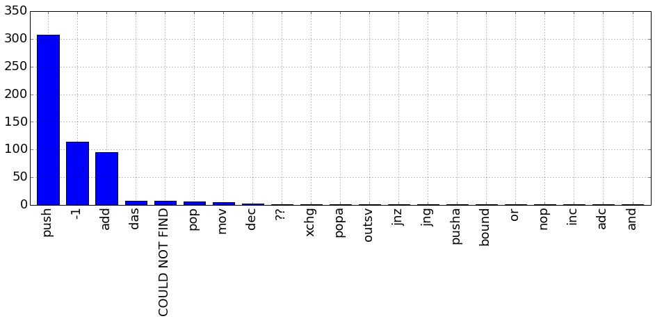

```python
df_entrypoint['entry point instruction type'].value_counts().plot(kind='bar')
```

```python
clf_final = sklearn.ensemble.RandomForestClassifier(n_estimators=50)
final_labels = list(df_all.columns.values)
final_labels.remove('label')
final_labels.remove('cputype')
final_labels.remove('LC_UNIXTHREAD')
final_labels.remove('LC_MAIN')
final_labels.remove('const strings')
final_labels.remove('symbol table strings')
final_labels.remove('segment names')
final_labels.remove('section names')
final_labels.remove('entry point section name')
final_labels.remove('entry point segment name')
final_labels.remove('entry point instruction type')
X_final = df_all.as_matrix(final_labels)
y_final = np.array(df_all['label'].tolist())
```

```python
scores = sklearn.cross_validation.cross_val_score(clf_final, X_final, y_final, cv=10, n_jobs=5)
print("Accuracy: %0.2f (+/- %0.2f)" % (scores.mean(), scores.std() * 2))
```

```
Accuracy: 0.96 (+/- 0.06)
```

```
Confusion Matrix Stats
good/good: 94.20% (65/69)
good/bad: 5.80% (4/69)
bad/good: 2.33% (1/43)
bad/bad: 97.67% (42/43)
```

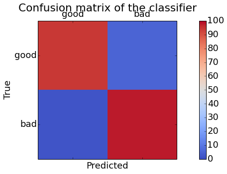

```python
# 80/20 Split for predictive test
X_train_final, X_test_final, y_train_final, y_test_final = train_test_split(X_final, y_final,
                                                                            test_size=my_tsize,
                                                                            random_state=my_seed)
clf_final.fit(X_train_final, y_train_final)
y_pred_final = clf_final.predict(X_test_final)
cm_final = confusion_matrix(y_test_final, y_pred_final, labels)
plot_cm(cm_final, labels)
```

### You can set threshold values to your priorities.

```
Confusion Matrix Stats
good/good: 98.55% (68/69)
good/bad: 1.45% (1/69)
bad/good: 16.28% (7/43)
bad/bad: 83.72% (36/43)
```

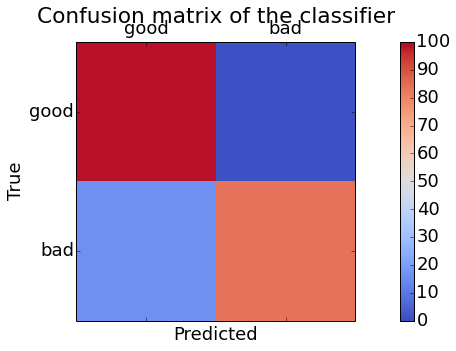

```python
y_probs_final = clf_final.predict_proba(X_test_final)[:,0]
thres = .8 # This can be set to whatever you'd like
y_pred_final[y_probs_final<thres] = 'good'
y_pred_final[y_probs_final>=thres] = 'bad'
cm = confusion_matrix(y_test_final, y_pred_final, labels)
plot_cm(cm, labels)
```

### Most important features

Now that we added in the g-scores from the strings of section names, segment names, and symbol table, now what are the most important features?

```python
importances = zip(final_labels, clf_final.feature_importances_)
importances.sort(key=lambda k:k[1], reverse=True)
for im in importances[0:20]:
    print im[0].ljust(35), im[1]
```

```
section names malicious_g           0.0657407559464
LC_SOURCE_VERSION                   0.0553265015965
section names clean_g               0.0535257311096
LC_DYLIB_CODE_SIGN_DRS              0.048614836495
LC_DATA_IN_CODE                     0.0464634185482
rebase_size                         0.043812886794
LC_CODE_SIGNATURE                   0.0334035056079
rebase_off                          0.0311568256564
text_section_align                  0.0232383559178
data_nsects                         0.021464002581
linkedit_vmsize                     0.0198348290427
lazy_bind_size                      0.0173961188418
pz_vmaddr                           0.0165259506433
pz_vmsize                           0.0156923760629
nextdefsym                          0.0152103851287
pz_fileoff                          0.0141570209658
entry point offset                  0.0140948505669
nlocrel                             0.0131386093896
bind_size                           0.0121543445893
pz_flags                            0.0120473460984
```

### Try a new classifier with only the 20 most important features

```
Confusion Matrix Stats
good/good: 92.75% (64/69)
good/bad: 7.25% (5/69)
bad/good: 2.33% (1/43)
bad/bad: 97.67% (42/43)
```

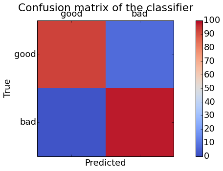

```python
clf_most = sklearn.ensemble.RandomForestClassifier(n_estimators=50)
X = df_all.as_matrix([item[0] for item in importances[:20]])
X_train, X_test, y_train, y_test = train_test_split(X, y, test_size=my_tsize, random_state=my_seed)
clf_most.fit(X_train, y_train)
y_pred = clf_most.predict(X_test)
cm = confusion_matrix(y_test, y_pred, labels)
plot_cm(cm, labels)
```

```
Confusion Matrix Stats
good/good: 98.55% (68/69)
good/bad: 1.45% (1/69)
bad/good: 20.93% (9/43)
bad/bad: 79.07% (34/43)
```

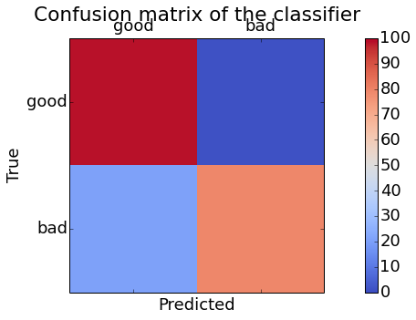

```python
y_probs = clf_most.predict_proba(X_test)[:,0]
thres = .92 # This can be set to whatever you'd like
y_pred[y_probs<thres] = 'good'
y_pred[y_probs>=thres] = 'bad'
cm = confusion_matrix(y_test, y_pred, labels)
plot_cm(cm, labels)
```

### Using a different classifier

Let's try a different classifier: Extra Trees Classifier (like RandomForest, but even more random).  
http://scikit-learn.org/stable/modules/generated/sklearn.ensemble.ExtraTreesClassifier.html

```
Confusion Matrix Stats
good/good: 94.20% (65/69)
good/bad: 5.80% (4/69)
bad/good: 2.33% (1/43)
bad/bad: 97.67% (42/43)
```

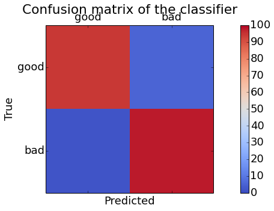

```python
clf_most = sklearn.ensemble.ExtraTreesClassifier(n_estimators=50)
X = df_all.as_matrix([item[0] for item in importances[:20]])
X_train, X_test, y_train, y_test = train_test_split(X, y, test_size=my_tsize, random_state=my_seed)
clf_most.fit(X_train, y_train)
y_pred = clf_most.predict(X_test)
cm = confusion_matrix(y_test, y_pred, labels)
plot_cm(cm, labels)
```

### Going one step further

It's nice to give a prediction on whether the binary is good or bad, but it would be nicer to include why that prediction is given. Let's explore the rebase_size and rebase_off features from the LC_DYLD_INFO command. The dyld_info_command contains the file offsets and sizes of the new compressed form of the information dyld needs to load the image.  
Dyld rebases an image whenever dyld loads it at an address different from its preferred address.

- rebase_off is the file offset to rebase info
- rebase_size is the size of rebase info

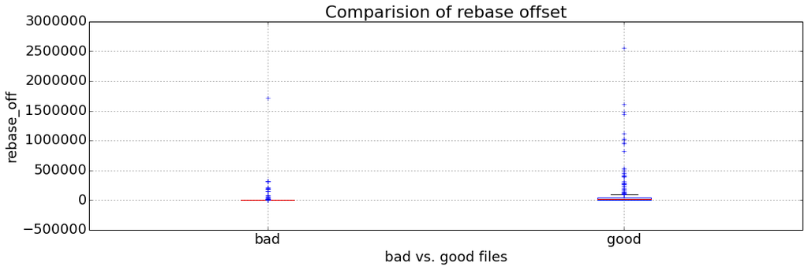

```python
df_all.boxplot(column='rebase_off', by='label')
plt.xlabel('bad vs. good files')
plt.ylabel('rebase_off')
plt.title('Comparision of rebase offset')
plt.suptitle("")
```

Not the most useful plot, let's try again, but not show the outliers.

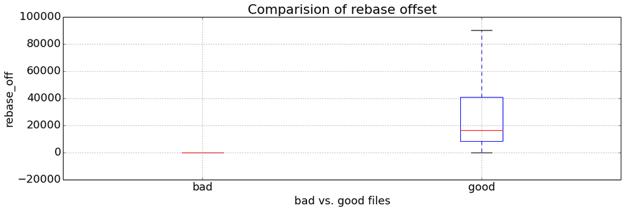

```python
df_all.boxplot(column='rebase_off', by='label', sym='')
plt.xlabel('bad vs. good files')
plt.ylabel('rebase_off')
plt.title('Comparision of rebase offset')
plt.suptitle("")
```

```python
cond = df_all['label'] == 'good'
good_all = df_all[cond]
bad_all  = df_all[~cond]
bvc = pd.DataFrame(bad_all['rebase_off'].value_counts(), columns=['count'])
bvc['perctange'] = bvc/bad_all.shape[0]
gvc = pd.DataFrame(good_all['rebase_off'].value_counts(), columns=['count'])
gvc['perctange'] = gvc/good_all.shape[0]
print 'Most common rebase_off values from malicious set'
print bvc.head(5)
print ''
print 'Most common rebase_off values from clean set'
print gvc.head()
```

```
Most common rebase_off values from malicious set
         count  perctange
 0         125   0.490196
-1          81   0.317647
 20480      10   0.039216
 8192       10   0.039216
 319488      4   0.015686

[5 rows x 2 columns]

Most common rebase_off values from clean set
        count  perctange
 8192      53   0.173770
 12288     49   0.160656
-1         29   0.095082
 16384     27   0.088525
 0         21   0.068852

[5 rows x 2 columns]
```

```
(-50, 3000000)
```

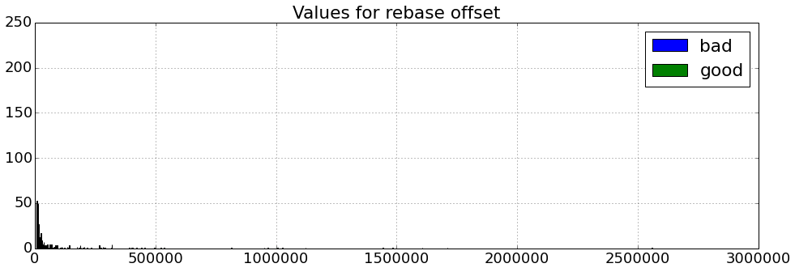

```python
bad_all['rebase_off'].hist(alpha=1,label='bad',bins=1000)
good_all['rebase_off'].hist(alpha=1,label='good',bins=1000)
plt.title('Values for rebase offset')
plt.legend()
plt.xlim(-50,3000000)
```

### Well, that wasn't very helpful, let's not show the long tail on the plot

```
(-50, 80000)
```

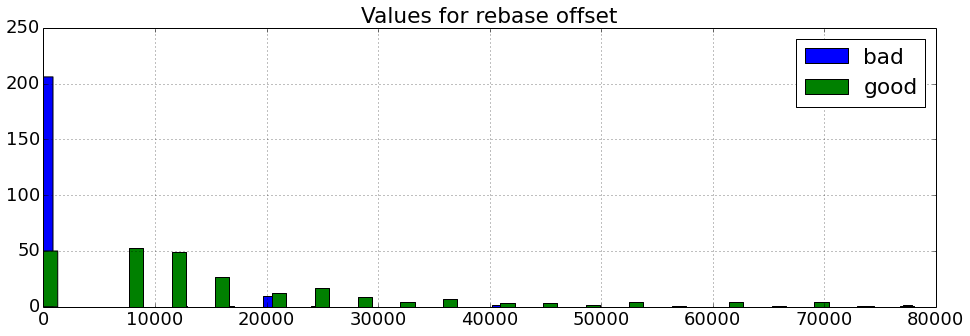

```python
bad_all['rebase_off'].hist(alpha=1,label='bad',bins=2000)
good_all['rebase_off'].hist(alpha=1,label='good',bins=2000)
plt.legend()
plt.title('Values for rebase offset')
plt.xlim(-50,80000)
```

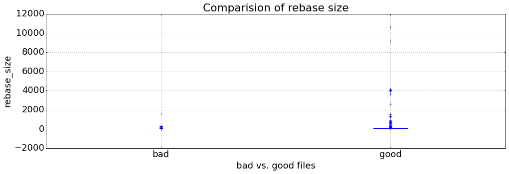

```python
df_all.boxplot(column='rebase_size', by='label')
plt.xlabel('bad vs. good files')
plt.ylabel('rebase_size')
plt.title('Comparision of rebase size')
plt.suptitle("")
```

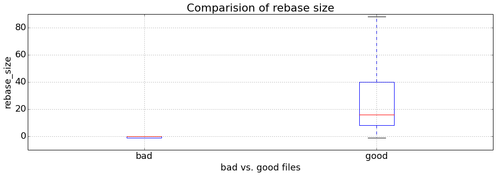

```python
df_all.boxplot(column='rebase_size', by='label', sym='')
plt.xlabel('bad vs. good files')
plt.ylabel('rebase_size')
plt.title('Comparision of rebase size')
plt.suptitle("")
```

```python
bvc = pd.DataFrame(bad_all['rebase_size'].value_counts(), columns=['count'])
bvc['percentange'] = bvc/bad_all.shape[0]
gvc = pd.DataFrame(good_all['rebase_size'].value_counts(), columns=['count'])
gvc['percentange'] = gvc/good_all.shape[0]
print 'Most common rebase_size values from malicious set'
print bvc.head(5)
print ''
print 'Most common rebase_size values from clean set'
print gvc.head(5)
```

```
Most common rebase_size values from malicious set
     count  percentange
 0     125     0.490196
-1      81     0.317647
 48      6     0.023529
 16      6     0.023529
 28      5     0.019608

[5 rows x 2 columns]

Most common rebase_size values from clean set
     count  percentange
 8      80     0.262295
 16     44     0.144262
-1      29     0.095082
 0      21     0.068852
 24     17     0.055738

[5 rows x 2 columns]
```

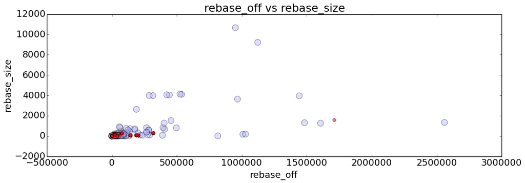

```python
plt.scatter(good_all['rebase_off'], good_all['rebase_size'],
            s=140, c='#aaaaff', label='Good', alpha=.4)
plt.scatter(bad_all['rebase_off'], bad['rebase_size'],
            s=40, c='r', label='Bad', alpha=.5)
plt.title('rebase_off vs rebase_size')
plt.xlabel('rebase_off')
plt.ylabel('rebase_size')
```

### Let's zoom in around the origin

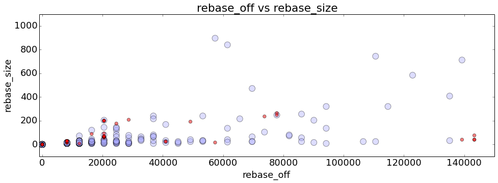

```python
plt.scatter(good_all['rebase_off'], good_all['rebase_size'],
            s=140, c='#aaaaff', label='Good', alpha=.4)
plt.scatter(bad_all['rebase_off'], bad['rebase_size'],
            s=40, c='r', label='Bad', alpha=.5)
plt.xlim(-1000,150000)
plt.ylim(-100,1100)
plt.title('rebase_off vs rebase_size')
plt.xlabel('rebase_off')
plt.ylabel('rebase_size')
```

```python
plt.scatter(good_all['rebase_off'], good_all['rebase_size'],
            s=140, c='#aaaaff', label='Good', alpha=.4)
plt.scatter(bad_all['rebase_off'], bad['rebase_size'],
            s=40, c='r', label='Bad', alpha=.5)
plt.xlim(-10,10)
plt.ylim(-10,10)
plt.title('rebase_off vs rebase_size')
plt.xlabel('rebase_off')
plt.ylabel('rebase_size')
```

[output not shown]

### How does current AV do on these files?

Scan data is as of 2014/04/28

```python
def load_vt_data(vt_list):
    import json
    import collections
    results = {}
    for filename in vt_list:
        with open(filename,'rb') as f:
            vt_data = f.read()
            if len(vt_data) == 0:
                break
            vt = json.loads(vt_data)
            for engine in vt['scans'].keys():
                if engine not in results:
                    results[engine] = 0
                if vt['scans'][engine]['detected']:
                    results[engine] += 1

    r = []
    for key, value in results.iteritems():
        r.append({'Engine': key, 'Count': value})
    return r
```

```python
vt_list = glob.glob('data/bad/vt_data/*.vtdata')
num_files = len(vt_list)
vt_results = load_vt_data(vt_list)
vt_df = pd.DataFrame.from_records(vt_results, columns=['Engine', 'Count'])
vt_df['Files Scanned'] = num_files
vt_df['Percentage'] = vt_df['Count']/num_files
vt_df.sort('Count', ascending=0).head(52)
```

|  | Engine | Count | Files Scanned | Percentage |
| --- | --- | --- | --- | --- |
| 18 | Avast | 261 | 261 | 1.000000 |
| 40 | GData | 261 | 261 | 1.000000 |
| 28 | F-Secure | 261 | 261 | 1.000000 |
| 25 | Ad-Aware | 260 | 261 | 0.996169 |
| 1 | MicroWorld-eScan | 260 | 261 | 0.996169 |
| 21 | BitDefender | 260 | 261 | 0.996169 |
| 20 | Kaspersky | 255 | 261 | 0.977011 |
| 34 | Emsisoft | 254 | 261 | 0.973180 |
| 2 | nProtect | 254 | 261 | 0.973180 |
| 45 | ESET-NOD32 | 254 | 261 | 0.973180 |
| 31 | AntiVir | 245 | 261 | 0.938697 |
| 27 | Comodo | 242 | 261 | 0.927203 |
| 26 | Sophos | 240 | 261 | 0.919540 |
| 29 | DrWeb | 240 | 261 | 0.919540 |
| 47 | Ikarus | 238 | 261 | 0.911877 |
| 19 | ClamAV | 231 | 261 | 0.885057 |
| 51 | Qihoo-360 | 230 | 261 | 0.881226 |
| 49 | AVG | 228 | 261 | 0.873563 |
| 4 | CAT-QuickHeal | 226 | 261 | 0.865900 |
| 12 | NANO-Antivirus | 224 | 261 | 0.858238 |
| 17 | TrendMicro-HouseCall | 203 | 261 | 0.777778 |
| 14 | Symantec | 190 | 261 | 0.727969 |
| 38 | Microsoft | 175 | 261 | 0.670498 |
| 42 | AhnLab-V3 | 170 | 261 | 0.651341 |
| 0 | Bkav | 149 | 261 | 0.570881 |
| 30 | VIPRE | 128 | 261 | 0.490421 |
| 32 | TrendMicro | 102 | 261 | 0.390805 |
| 5 | McAfee | 90 | 261 | 0.344828 |
| 33 | McAfee-GW-Edition | 90 | 261 | 0.344828 |
| 23 | ViRobot | 85 | 261 | 0.325670 |
| 15 | Norman | 55 | 261 | 0.210728 |
| 46 | Rising | 49 | 261 | 0.187739 |
| 13 | F-Prot | 42 | 261 | 0.160920 |
| 41 | Commtouch | 41 | 261 | 0.157088 |
| 35 | Jiangmin | 40 | 261 | 0.153257 |
| 9 | K7AntiVirus | 36 | 261 | 0.137931 |
| 10 | K7GW | 35 | 261 | 0.134100 |
| 16 | TotalDefense | 34 | 261 | 0.130268 |
| 48 | Fortinet | 27 | 261 | 0.103448 |
| 22 | Agnitum | 26 | 261 | 0.099617 |
| 43 | VBA32 | 25 | 261 | 0.095785 |
| 7 | Zillya | 21 | 261 | 0.080460 |
| 50 | Panda | 11 | 261 | 0.042146 |
| 3 | CMC | 5 | 261 | 0.019157 |
| 36 | Antiy-AVL | 1 | 261 | 0.003831 |
| 24 | ByteHero | 0 | 261 | 0.000000 |
| 44 | Baidu-International | 0 | 261 | 0.000000 |
| 6 | Malwarebytes | 0 | 261 | 0.000000 |
| 11 | TheHacker | 0 | 261 | 0.000000 |
| 39 | AegisLab | 0 | 261 | 0.000000 |
| 37 | Kingsoft | 0 | 261 | 0.000000 |
| 8 | SUPERAntiSpyware | 0 | 261 | 0.000000 |

52 rows × 4 columns

```python
vt_list = glob.glob('data/good/vt_data/*.vtdata')
num_files = len(vt_list)
vt_results = load_vt_data(vt_list)
vt_df = pd.DataFrame.from_records(vt_results, columns=['Engine', 'Count'])
vt_df['Files Scanned'] = num_files
vt_df['Percentage'] = vt_df['Count']/num_files
vt_df.sort('Count', ascending=0).head(15)
```

|  | Engine | Count | Files Scanned | Percentage |
| --- | --- | --- | --- | --- |
| 51 | Qihoo-360 | 0 | 266 | 0 |
| 50 | Panda | 0 | 266 | 0 |
| 23 | SUPERAntiSpyware | 0 | 266 | 0 |
| 22 | NANO-Antivirus | 0 | 266 | 0 |
| 21 | BitDefender | 0 | 266 | 0 |
| 20 | Kaspersky | 0 | 266 | 0 |
| 19 | ClamAV | 0 | 266 | 0 |
| 18 | Avast | 0 | 266 | 0 |
| 17 | TrendMicro-HouseCall | 0 | 266 | 0 |
| 16 | TotalDefense | 0 | 266 | 0 |
| 15 | Norman | 0 | 266 | 0 |
| 14 | Symantec | 0 | 266 | 0 |
| 13 | F-Prot | 0 | 266 | 0 |
| 12 | Agnitum | 0 | 266 | 0 |
| 11 | K7AntiVirus | 0 | 266 | 0 |

15 rows × 4 columns